# IE 360 Spring 24' Project

## 2024-06-05

### Yaren Ezgi Işık 2019402063

### Furkan Çelen 2019402102

### Enes Furkan Pekalkan 2018402261

## Introduction

States encourage the use of environmentally friendly renewable energy sources instead of fossil fuels due to the damage they cause to the environment. Solar energy is also among the renewable energy sources. European Union funds provide funding to companies that produce solar energy. One of the biggest problems encountered when producing electrical energy is storage. Therefore, it is essential for energy efficiency to distribute the electricity produced to the regions in need as it is produced. Therefore, it is useful to forecast the electricity produced almost accurately with previous data.

```r
options(warn=-1) #suppress warnings
require(data.table)
require(lubridate)
require(zoo)
library(forecast)
library(tseries)
library(ggplot2)
require(urca)
library(dplyr)
library(GGally)
data_path="C:/Users/DELL/Desktop/360_proje/production_22.csv"
production = fread(data_path)
production[,date:=as.Date(date)]


# Loading and preparing data
data_path = "C:/Users/DELL/Desktop/360_proje/processed_weather.csv"
weather_info = fread(data_path)
weather_info = weather_info[complete.cases(weather_info)]
weather_info[, datetime := ymd(date) + dhours(hour)]
weather_info = weather_info[order(datetime)]

# Aggregating daily data with relevant weather metrics, grouped by date, hour, lat, lon, etc.
daily_series = weather_info[, .(
    DSWRF_surface = sum(dswrf_surface),
    TCDC_low_cloud = sum(tcdc_low.cloud.layer),
    TCDC_middle_cloud = sum(tcdc_middle.cloud.layer),
    TCDC_high_cloud = sum(tcdc_high.cloud.layer),
    TCDC_entire_atmosphere = sum(tcdc_entire.atmosphere),
    USWRF_top_of_atmosphere = sum(uswrf_top_of_atmosphere),
    CSNOW_surface = sum(csnow_surface),
    DLWRF_surface = sum(dlwrf_surface),
    USRWF_surface = sum(uswrf_surface),
    TMP_surface = sum(tmp_surface)
), by = .(date, hour, lat, lon)]

# Melting into long format, keeping 'date', 'hour', 'lat', 'lon' as id.vars
long_format = melt(daily_series, id.vars = c("date", "hour", "lat", "lon"), measure.vars = names(daily_series)[-1:-4], variable.name = "metric", value.name = "value")

# Create a new identifier for each unique combination of metric, lat, and lon
long_format[, identifier := paste(metric, lat, lon, sep = "_")]

# Reshaping into wide format with 'date' and 'hour' as keys
wide_weather = dcast(long_format, date + hour ~ identifier, value.var = "value")

# Arranging'date' and 'hour' next to each other
setcolorder(wide_weather, c("date", "hour", names(wide_weather)[-1:-2]))
dim(wide_weather)
str(wide_weather)
```

1. 21106

2. 252

```
Classes ‘data.table’ and 'data.frame':	21106 obs. of  252 variables:
 $ date                               : IDate, format: "2022-01-01" "2022-01-01" ...
 $ hour                               : int  4 5 6 7 8 9 10 11 12 13 ...
 $ CSNOW_surface_37.75_34.5           : num  0 0 0 0 0 0 0 0 0 0 ...
 $ CSNOW_surface_37.75_34.75          : num  0 0 0 0 0 0 0 0 0 0 ...
 $ CSNOW_surface_37.75_35             : num  0 0 0 0 0 0 0 0 0 0 ...
 $ CSNOW_surface_37.75_35.25          : num  0 0 0 0 0 0 0 0 0 0 ...
 $ CSNOW_surface_37.75_35.5           : num  0 0 0 0 0 0 0 0 0 0 ...
 $ CSNOW_surface_38.25_34.5           : num  0 0 0 0 0 0 0 0 0 0 ...
 $ CSNOW_surface_38.25_34.75          : num  0 0 0 0 0 0 0 0 0 0 ...
 $ CSNOW_surface_38.25_35             : num  0 0 0 0 0 0 0 0 0 0 ...
 $ CSNOW_surface_38.25_35.25          : num  0 0 0 0 0 0 0 0 0 0 ...
 $ CSNOW_surface_38.25_35.5           : num  0 0 0 0 0 0 0 0 0 0 ...
 $ CSNOW_surface_38.5_34.5            : num  0 0 0 0 0 0 0 0 0 0 ...
 $ CSNOW_surface_38.5_34.75           : num  0 0 0 0 0 0 0 0 0 0 ...
```

[output cut: 88 more lines]

```r
#Putting together wide form of weather and production data
data =merge(wide_weather,production,by = c('date','hour'),all.x =T)
data <- data[order(date,hour)]
str(data)
data
```

```
Classes ‘data.table’ and 'data.frame':	21106 obs. of  253 variables:
 $ date                               : IDate, format: "2022-01-01" "2022-01-01" ...
 $ hour                               : int  4 5 6 7 8 9 10 11 12 13 ...
 $ CSNOW_surface_37.75_34.5           : num  0 0 0 0 0 0 0 0 0 0 ...
 $ CSNOW_surface_37.75_34.75          : num  0 0 0 0 0 0 0 0 0 0 ...
 $ CSNOW_surface_37.75_35             : num  0 0 0 0 0 0 0 0 0 0 ...
 $ CSNOW_surface_37.75_35.25          : num  0 0 0 0 0 0 0 0 0 0 ...
 $ CSNOW_surface_37.75_35.5           : num  0 0 0 0 0 0 0 0 0 0 ...
 $ CSNOW_surface_38.25_34.5           : num  0 0 0 0 0 0 0 0 0 0 ...
 $ CSNOW_surface_38.25_34.75          : num  0 0 0 0 0 0 0 0 0 0 ...
 $ CSNOW_surface_38.25_35             : num  0 0 0 0 0 0 0 0 0 0 ...
 $ CSNOW_surface_38.25_35.25          : num  0 0 0 0 0 0 0 0 0 0 ...
 $ CSNOW_surface_38.25_35.5           : num  0 0 0 0 0 0 0 0 0 0 ...
 $ CSNOW_surface_38.5_34.5            : num  0 0 0 0 0 0 0 0 0 0 ...
 $ CSNOW_surface_38.5_34.75           : num  0 0 0 0 0 0 0 0 0 0 ...
```

[output cut: 88 more lines]

A data.table: 21106 × 253

| date <IDate> | hour <int> | CSNOW_surface_37.75_34.5 <dbl> | CSNOW_surface_37.75_34.75 <dbl> | CSNOW_surface_37.75_35 <dbl> | CSNOW_surface_37.75_35.25 <dbl> | CSNOW_surface_37.75_35.5 <dbl> | CSNOW_surface_38.25_34.5 <dbl> | CSNOW_surface_38.25_34.75 <dbl> | CSNOW_surface_38.25_35 <dbl> | ⋯ | USWRF_top_of_atmosphere_38.75_34.75 <dbl> | USWRF_top_of_atmosphere_38.75_35 <dbl> | USWRF_top_of_atmosphere_38.75_35.25 <dbl> | USWRF_top_of_atmosphere_38.75_35.5 <dbl> | USWRF_top_of_atmosphere_38_34.5 <dbl> | USWRF_top_of_atmosphere_38_34.75 <dbl> | USWRF_top_of_atmosphere_38_35 <dbl> | USWRF_top_of_atmosphere_38_35.25 <dbl> | USWRF_top_of_atmosphere_38_35.5 <dbl> | production <dbl> |
| --- | --- | --- | --- | --- | --- | --- | --- | --- | --- | --- | --- | --- | --- | --- | --- | --- | --- | --- | --- | --- |
| 2022-01-01 | 4 | 0 | 0 | 0 | 0 | 0 | 0 | 0 | 0 | ⋯ | 0.000 | 0.000 | 0.000 | 0.000 | 0.000 | 0.000 | 0.000 | 0.000 | 0.000 | 0.00 |
| 2022-01-01 | 5 | 0 | 0 | 0 | 0 | 0 | 0 | 0 | 0 | ⋯ | 0.000 | 0.000 | 0.000 | 0.000 | 0.000 | 0.000 | 0.000 | 0.000 | 0.000 | 0.00 |
| 2022-01-01 | 6 | 0 | 0 | 0 | 0 | 0 | 0 | 0 | 0 | ⋯ | 0.000 | 0.000 | 0.000 | 0.000 | 0.000 | 0.000 | 0.000 | 0.000 | 0.000 | 0.00 |
| 2022-01-01 | 7 | 0 | 0 | 0 | 0 | 0 | 0 | 0 | 0 | ⋯ | 0.000 | 0.000 | 0.000 | 0.000 | 0.000 | 0.000 | 0.000 | 0.000 | 0.000 | 0.00 |
| 2022-01-01 | 8 | 0 | 0 | 0 | 0 | 0 | 0 | 0 | 0 | ⋯ | 0.000 | 0.000 | 0.000 | 0.000 | 0.000 | 0.000 | 0.000 | 0.000 | 0.000 | 3.40 |
| 2022-01-01 | 9 | 0 | 0 | 0 | 0 | 0 | 0 | 0 | 0 | ⋯ | 8.096 | 8.592 | 8.848 | 8.704 | 9.104 | 8.624 | 9.552 | 10.512 | 10.272 | 6.80 |
| 2022-01-01 | 10 | 0 | 0 | 0 | 0 | 0 | 0 | 0 | 0 | ⋯ | 105.264 | 120.656 | 137.664 | 142.336 | 133.104 | 132.960 | 162.352 | 179.808 | 177.152 | 9.38 |
| 2022-01-01 | 11 | 0 | 0 | 0 | 0 | 0 | 0 | 0 | 0 | ⋯ | 127.472 | 130.512 | 142.112 | 147.088 | 160.240 | 148.576 | 182.608 | 210.560 | 212.928 | 7.65 |
| 2022-01-01 | 12 | 0 | 0 | 0 | 0 | 0 | 0 | 0 | 0 | ⋯ | 141.328 | 140.320 | 150.656 | 150.096 | 179.024 | 165.360 | 201.632 | 234.480 | 234.352 | 6.80 |
| 2022-01-01 | 13 | 0 | 0 | 0 | 0 | 0 | 0 | 0 | 0 | ⋯ | 157.712 | 161.376 | 168.096 | 154.944 | 195.552 | 177.776 | 213.792 | 251.424 | 248.272 | 5.10 |
| 2022-01-01 | 14 | 0 | 0 | 0 | 0 | 0 | 0 | 0 | 0 | ⋯ | 165.664 | 167.312 | 173.920 | 163.232 | 201.872 | 183.472 | 217.664 | 259.952 | 253.232 | 5.10 |
| 2022-01-01 | 15 | 0 | 0 | 0 | 0 | 0 | 0 | 0 | 0 | ⋯ | 172.560 | 171.136 | 177.088 | 168.960 | 204.096 | 183.040 | 215.136 | 259.856 | 249.712 | 1.70 |
| 2022-01-01 | 16 | 0 | 0 | 0 | 0 | 0 | 0 | 0 | 0 | ⋯ | 167.856 | 165.584 | 149.936 | 148.976 | 186.688 | 151.424 | 167.536 | 219.200 | 185.264 | 0.00 |
| 2022-01-01 | 17 | 0 | 0 | 0 | 0 | 0 | 0 | 0 | 0 | ⋯ | 138.080 | 133.008 | 120.208 | 114.304 | 148.992 | 121.104 | 130.736 | 165.504 | 141.408 | 0.00 |
| 2022-01-01 | 18 | 0 | 0 | 0 | 0 | 0 | 0 | 0 | 0 | ⋯ | 95.632 | 91.904 | 82.928 | 78.464 | 104.016 | 84.560 | 90.816 | 113.904 | 97.232 | 0.00 |
| 2022-01-01 | 19 | 0 | 0 | 0 | 0 | 0 | 0 | 0 | 0 | ⋯ | 71.728 | 68.928 | 62.192 | 58.848 | 78.000 | 63.424 | 68.096 | 85.424 | 72.912 | 0.00 |
| 2022-01-01 | 20 | 0 | 0 | 0 | 0 | 0 | 0 | 0 | 0 | ⋯ | 57.376 | 55.152 | 49.760 | 47.072 | 62.416 | 50.736 | 54.480 | 68.336 | 58.336 | 0.00 |
| 2022-01-01 | 21 | 0 | 0 | 0 | 0 | 0 | 0 | 0 | 0 | ⋯ | 47.808 | 45.952 | 41.472 | 39.232 | 52.000 | 42.288 | 45.392 | 56.944 | 48.624 | 0.00 |
| 2022-01-01 | 22 | 0 | 0 | 0 | 0 | 0 | 0 | 0 | 0 | ⋯ | 0.000 | 0.000 | 0.000 | 0.000 | 0.000 | 0.000 | 0.000 | 0.000 | 0.000 | 0.00 |
| 2022-01-01 | 23 | 0 | 0 | 0 | 0 | 0 | 0 | 0 | 0 | ⋯ | 0.000 | 0.000 | 0.000 | 0.000 | 0.000 | 0.000 | 0.000 | 0.000 | 0.000 | 0.00 |
| 2022-01-02 | 0 | 0 | 0 | 0 | 0 | 0 | 0 | 0 | 0 | ⋯ | 0.000 | 0.000 | 0.000 | 0.000 | 0.000 | 0.000 | 0.000 | 0.000 | 0.000 | 0.00 |
| 2022-01-02 | 1 | 0 | 0 | 0 | 0 | 0 | 1 | 0 | 0 | ⋯ | 0.000 | 0.000 | 0.000 | 0.000 | 0.000 | 0.000 | 0.000 | 0.000 | 0.000 | 0.00 |
| 2022-01-02 | 2 | 0 | 1 | 0 | 0 | 0 | 1 | 0 | 0 | ⋯ | 0.000 | 0.000 | 0.000 | 0.000 | 0.000 | 0.000 | 0.000 | 0.000 | 0.000 | 0.00 |
| 2022-01-02 | 3 | 0 | 1 | 1 | 0 | 0 | 1 | 0 | 0 | ⋯ | 0.000 | 0.000 | 0.000 | 0.000 | 0.000 | 0.000 | 0.000 | 0.000 | 0.000 | 0.00 |
| 2022-01-02 | 4 | 0 | 1 | 1 | 1 | 0 | 1 | 1 | 1 | ⋯ | 0.000 | 0.000 | 0.000 | 0.000 | 0.000 | 0.000 | 0.000 | 0.000 | 0.000 | 0.00 |
| 2022-01-02 | 5 | 0 | 1 | 1 | 1 | 0 | 1 | 1 | 0 | ⋯ | 0.000 | 0.000 | 0.000 | 0.000 | 0.000 | 0.000 | 0.000 | 0.000 | 0.000 | 0.00 |
| 2022-01-02 | 6 | 0 | 1 | 1 | 1 | 0 | 1 | 1 | 1 | ⋯ | 0.000 | 0.000 | 0.000 | 0.000 | 0.000 | 0.000 | 0.000 | 0.000 | 0.000 | 0.00 |
| 2022-01-02 | 7 | 0 | 1 | 1 | 1 | 0 | 1 | 1 | 1 | ⋯ | 0.000 | 0.000 | 0.000 | 0.000 | 0.000 | 0.000 | 0.000 | 0.000 | 0.000 | 0.00 |
| 2022-01-02 | 8 | 0 | 1 | 1 | 1 | 0 | 1 | 1 | 1 | ⋯ | 0.000 | 0.000 | 0.000 | 0.000 | 0.000 | 0.000 | 0.000 | 0.000 | 0.000 | 0.00 |
| 2022-01-02 | 9 | 0 | 1 | 1 | 1 | 0 | 1 | 1 | 1 | ⋯ | 12.208 | 12.816 | 13.232 | 13.648 | 13.200 | 13.696 | 13.696 | 13.856 | 14.288 | 0.85 |
| ⋮ | ⋮ | ⋮ | ⋮ | ⋮ | ⋮ | ⋮ | ⋮ | ⋮ | ⋮ | ⋱ | ⋮ | ⋮ | ⋮ | ⋮ | ⋮ | ⋮ | ⋮ | ⋮ | ⋮ | ⋮ |
| 2024-05-28 | 16 | 0 | 0 | 0 | 0 | 0 | 0 | 0 | 0 | ⋯ | 596.352 | 593.072 | 505.456 | 340.544 | 176.544 | 178.304 | 339.328 | 543.552 | 567.568 | NA |
| 2024-05-28 | 17 | 0 | 0 | 0 | 0 | 0 | 0 | 0 | 0 | ⋯ | 564.576 | 570.432 | 521.616 | 440.320 | 176.992 | 178.864 | 353.776 | 498.128 | 463.120 | NA |
| 2024-05-28 | 18 | 0 | 0 | 0 | 0 | 0 | 0 | 0 | 0 | ⋯ | 462.976 | 504.208 | 479.792 | 416.832 | 168.032 | 166.704 | 336.304 | 468.352 | 370.832 | NA |
| 2024-05-28 | 19 | 0 | 0 | 0 | 0 | 0 | 0 | 0 | 0 | ⋯ | 372.960 | 407.840 | 402.080 | 345.744 | 152.848 | 151.472 | 288.928 | 404.640 | 329.344 | NA |
| 2024-05-28 | 20 | 0 | 0 | 0 | 0 | 0 | 0 | 0 | 0 | ⋯ | 305.104 | 332.944 | 327.904 | 282.464 | 129.040 | 128.608 | 238.032 | 331.232 | 271.920 | NA |
| 2024-05-28 | 21 | 0 | 0 | 0 | 0 | 0 | 0 | 0 | 0 | ⋯ | 254.256 | 277.456 | 273.248 | 235.392 | 107.536 | 107.184 | 198.368 | 276.032 | 226.592 | NA |
| 2024-05-28 | 22 | 0 | 0 | 0 | 0 | 0 | 0 | 0 | 0 | ⋯ | 0.000 | 0.000 | 0.000 | 0.000 | 0.000 | 0.000 | 0.000 | 0.000 | 0.000 | NA |
| 2024-05-28 | 23 | 0 | 0 | 0 | 0 | 0 | 0 | 0 | 0 | ⋯ | 0.000 | 0.000 | 0.000 | 0.000 | 0.000 | 0.000 | 0.000 | 0.000 | 0.000 | NA |
| 2024-05-29 | 0 | 0 | 0 | 0 | 0 | 0 | 0 | 0 | 0 | ⋯ | 0.000 | 0.000 | 0.000 | 0.000 | 0.000 | 0.000 | 0.000 | 0.000 | 0.000 | NA |
| 2024-05-29 | 1 | 0 | 0 | 0 | 0 | 0 | 0 | 0 | 0 | ⋯ | 0.000 | 0.000 | 0.000 | 0.000 | 0.000 | 0.000 | 0.000 | 0.000 | 0.000 | NA |
| 2024-05-29 | 2 | 0 | 0 | 0 | 0 | 0 | 0 | 0 | 0 | ⋯ | 0.000 | 0.000 | 0.000 | 0.000 | 0.000 | 0.000 | 0.000 | 0.000 | 0.000 | NA |
| 2024-05-29 | 3 | 0 | 0 | 0 | 0 | 0 | 0 | 0 | 0 | ⋯ | 0.000 | 0.000 | 0.000 | 0.000 | 0.000 | 0.000 | 0.000 | 0.000 | 0.000 | NA |
| 2024-05-29 | 4 | 0 | 0 | 0 | 0 | 0 | 0 | 0 | 0 | ⋯ | 0.000 | 0.000 | 0.000 | 0.000 | 0.000 | 0.000 | 0.000 | 0.000 | 0.000 | NA |
| 2024-05-29 | 5 | 0 | 0 | 0 | 0 | 0 | 0 | 0 | 0 | ⋯ | 0.000 | 0.000 | 0.000 | 0.000 | 0.000 | 0.000 | 0.000 | 0.000 | 0.000 | NA |
| 2024-05-29 | 6 | 0 | 0 | 0 | 0 | 0 | 0 | 0 | 0 | ⋯ | 5.200 | 5.504 | 5.680 | 5.856 | 4.352 | 4.624 | 4.944 | 5.312 | 8.192 | NA |
| 2024-05-29 | 7 | 0 | 0 | 0 | 0 | 0 | 0 | 0 | 0 | ⋯ | 25.328 | 25.744 | 25.312 | 26.992 | 23.296 | 23.936 | 24.320 | 25.072 | 32.336 | NA |
| 2024-05-29 | 8 | 0 | 0 | 0 | 0 | 0 | 0 | 0 | 0 | ⋯ | 46.944 | 47.280 | 45.840 | 46.544 | 43.680 | 44.640 | 44.720 | 45.760 | 52.256 | NA |
| 2024-05-29 | 9 | 0 | 0 | 0 | 0 | 0 | 0 | 0 | 0 | ⋯ | 66.240 | 66.432 | 63.904 | 63.328 | 61.824 | 63.072 | 62.752 | 63.824 | 69.248 | NA |
| 2024-05-29 | 10 | 0 | 0 | 0 | 0 | 0 | 0 | 0 | 0 | ⋯ | 180.944 | 180.048 | 170.272 | 160.912 | 169.184 | 172.272 | 169.040 | 168.320 | 156.480 | NA |
| 2024-05-29 | 11 | 0 | 0 | 0 | 0 | 0 | 0 | 0 | 0 | ⋯ | 186.432 | 185.392 | 174.992 | 165.184 | 174.192 | 177.440 | 174.432 | 184.928 | 160.672 | NA |
| 2024-05-29 | 12 | 0 | 0 | 0 | 0 | 0 | 0 | 0 | 0 | ⋯ | 190.240 | 189.056 | 178.240 | 168.144 | 177.664 | 181.120 | 193.040 | 288.848 | 165.952 | NA |
| 2024-05-29 | 13 | 0 | 0 | 0 | 0 | 0 | 0 | 0 | 0 | ⋯ | 192.704 | 191.392 | 180.288 | 170.048 | 179.824 | 186.960 | 282.544 | 428.272 | 176.144 | NA |
| 2024-05-29 | 14 | 0 | 0 | 0 | 0 | 0 | 0 | 0 | 0 | ⋯ | 193.904 | 192.480 | 181.248 | 171.776 | 180.832 | 210.032 | 376.064 | 512.240 | 257.616 | NA |
| 2024-05-29 | 15 | 0 | 0 | 0 | 0 | 0 | 0 | 0 | 0 | ⋯ | 193.808 | 192.288 | 184.976 | 207.840 | 180.752 | 226.368 | 389.360 | 526.432 | 286.320 | NA |
| 2024-05-29 | 16 | 0 | 0 | 0 | 0 | 0 | 0 | 0 | 0 | ⋯ | 183.488 | 181.696 | 171.776 | 388.992 | 171.856 | 283.312 | 360.048 | 178.096 | 174.016 | NA |
| 2024-05-29 | 17 | 0 | 0 | 0 | 0 | 0 | 0 | 0 | 0 | ⋯ | 175.424 | 173.728 | 164.512 | 277.664 | 196.816 | 246.048 | 271.440 | 168.720 | 197.136 | NA |
| 2024-05-29 | 18 | 0 | 0 | 0 | 0 | 0 | 0 | 0 | 0 | ⋯ | 213.536 | 163.216 | 166.160 | 228.336 | 217.296 | 232.800 | 233.968 | 159.232 | 204.304 | NA |
| 2024-05-29 | 19 | 0 | 0 | 0 | 0 | 0 | 0 | 0 | 0 | ⋯ | 199.376 | 148.592 | 153.904 | 200.992 | 205.552 | 216.416 | 208.320 | 143.312 | 177.040 | NA |
| 2024-05-29 | 20 | 0 | 0 | 0 | 0 | 0 | 0 | 0 | 0 | ⋯ | 169.360 | 125.504 | 129.264 | 166.592 | 173.072 | 182.800 | 174.704 | 120.496 | 147.168 | NA |
| 2024-05-29 | 21 | 0 | 0 | 0 | 0 | 0 | 0 | 0 | 0 | ⋯ | 141.120 | 104.592 | 107.728 | 138.832 | 144.224 | 152.336 | 145.584 | 100.416 | 122.640 | NA |

### Hourly Production Plots

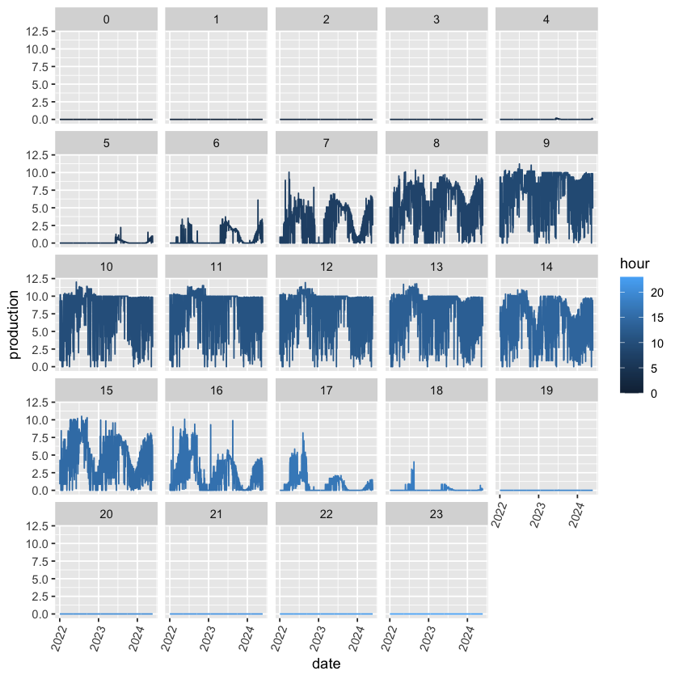

```r
train_start=as.Date('2022-01-02')
test_start= as.Date('2024-02-01')
test_end = as.Date('2024-05-20')
ggplot(data[date>=train_start],aes(x=date,y=production,col=hour))+geom_line()+facet_wrap(~hour)+theme(axis.text.x=element_text(angle=70, hjust=1.4, vjust = 1.4))
```

The above figure depicts hourly solar power production across various times of the day from 2022 to 2024. The x-axis represents the date range, while the y-axis shows production levels. Each panel corresponds to a specific hour of the day. The graph clearly demonstrates that there is no production from 19:00 to 4:00. Additionally, there is a noticeable seasonal pattern, with higher production levels observed during daylight hours and reduced production during the winter months, reflecting the impact of shorter daylight periods on solar power generation.

### Daily Production Plot

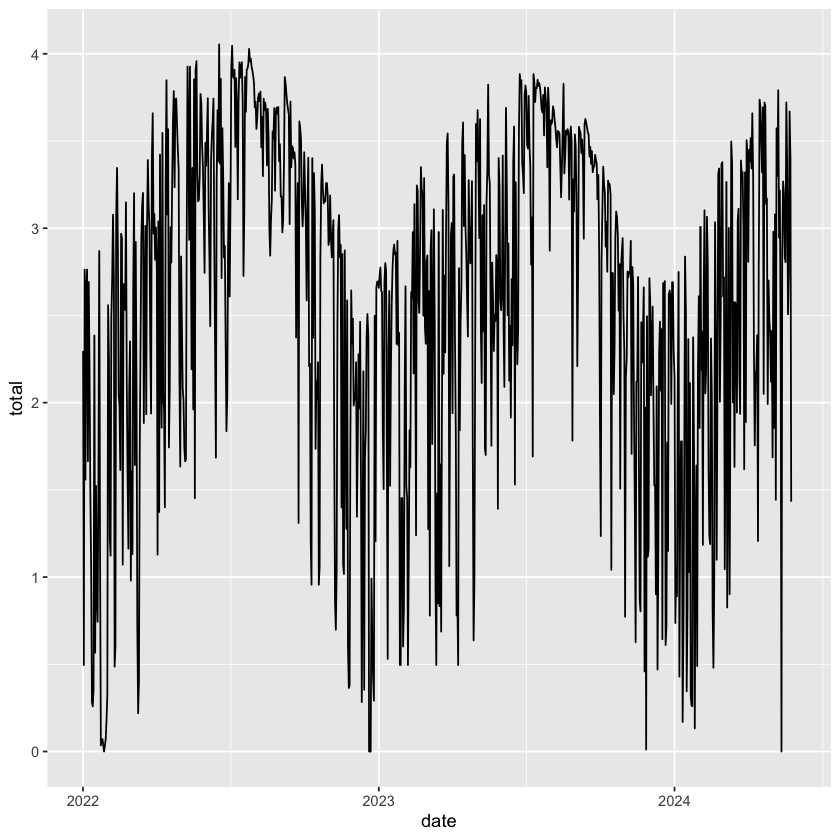

```r
daily_series=data[,list(total=mean(production)),list(date)]
ggplot(daily_series,aes(x=date,y=total))+geom_line()
```

The graph above depicts daily solar power production from 2022 to 2024. The x-axis represents the date range, while the y-axis shows the total production levels. The data shows production levels ranging from approximately 0 to over 4. There is a clear seasonal pattern, with production peaking in the summer months and declining in the winter months. The variability within each year, with peaks and troughs, suggests changes in weather conditions, solar irradiance, and possibly maintenance activities. This indicates the need for a more stable and smooth production model to handle these fluctuations better.

### Partial Autocorrelation and Autocorrelation of Hourly Production

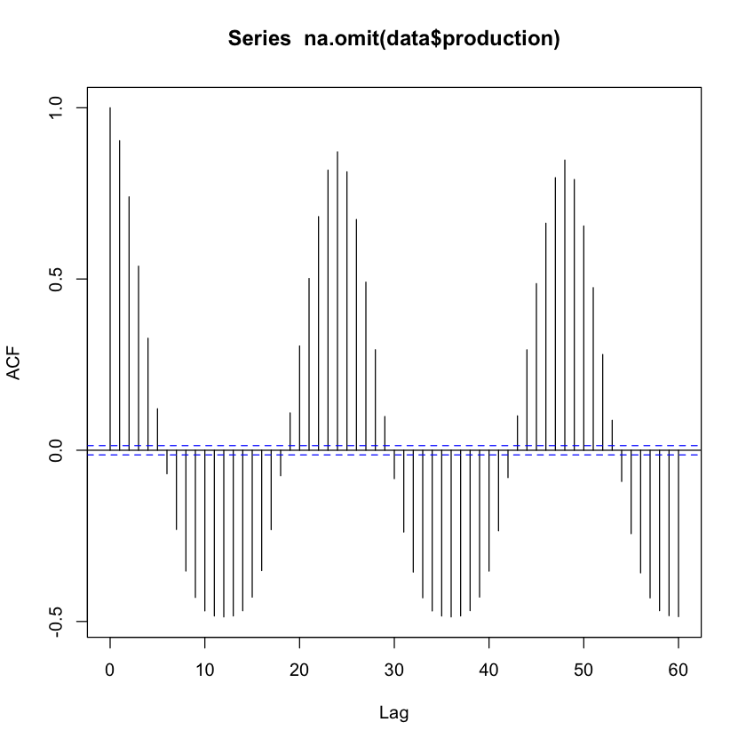

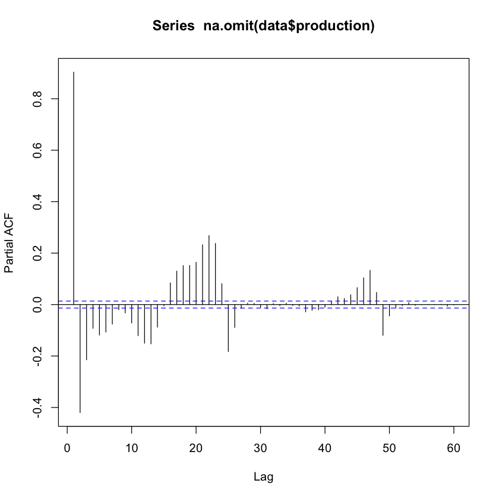

```r
acf(na.omit(data$production),lag.max = 60)
pacf(na.omit(data$production),lag.max = 60)
```

The first figure above represents the Autocorrelation Function (ACF) of the solar power production data. Significant spikes at certain lags, especially at lag 24, indicate a strong daily seasonality in the data. This implies that production at a given hour is highly correlated with the production at the same hour on the previous day. The second figure illustrates the Partial Autocorrelation Function (PACF) of the dataset. The spikes at lag 1 and lag 25 suggest that the immediate past hour and the same hour on the previous day have significant direct impacts on the current production values. Both figures confirm the presence of daily patterns in solar power production, with strong correlations observed at 24-hour intervals. This indicates that the production levels are influenced by consistent daily cycles, likely driven by solar irradiance and environmental conditions that follow a daily rhythm.

### 1) Linear Regression and Time Series Regression

Given the seasonal behaviour of the data (hourly, monthly, and seasonally), using weather data with time-related regressors is an effective approach. Models are developed step by step by adding regressors, and their performance is measured using adjusted R-squared and residual plots. Due to the large number of rows in the weather data, it is averaged over 25 coordinates, and a ggpairs plot is created to analyze the regressors more effectively. These models forecast from 06:00 to 18:00 because there is no significant production outside these hours, making it unnecessary to predict for those times.

#### 1.a Model with Averaged Data

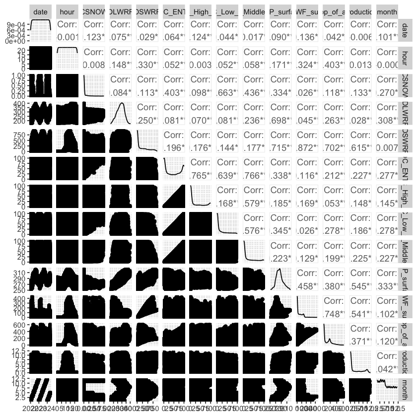

```r
avgdata=data.table(date=data$date,hour=data$hour,CSNOW=rowSums(data[,3:27])/25,DLWRF=rowSums(data[,28:52])/25,DSWRF=rowSums(data[,53:77])/25,TCDC_ENTIRE=rowSums(data[,78:102])/25,TCDC_High_Cloud=rowSums(data[,103:127])/25,TCDC_Low_Cloud=rowSums(data[,128:152])/25,TCDC_Middle_Cloud=rowSums(data[,153:177])/25,TMP_surface=rowSums(data[,178:202])/25,USRWF_surface=rowSums(data[,203:227])/25,USWRF_top_of_atmosphere=rowSums(data[,228:252])/25,production=data$production,month=as.numeric(format(data$date,format="%m")))

avgweather=data.table(date=wide_weather$date,hour=wide_weather$hour,CSNOW=rowSums(data[,3:27])/25,DLWRF=rowSums(data[,28:52])/25,DSWRF=rowSums(data[,53:77])/25,TCDC_ENTIRE=rowSums(data[,78:102])/25,TCDC_High_Cloud=rowSums(data[,103:127])/25,TCDC_Low_Cloud=rowSums(data[,128:152])/25,TCDC_Middle_Cloud=rowSums(data[,153:177])/25,TMP_surface=rowSums(data[,178:202])/25,USRWF_surface=rowSums(data[,203:227])/25,USWRF_top_of_atmosphere=rowSums(data[,228:252])/25)
#avgweather

model_avg = lm(production~.-date-hour-month-production,avgdata[hour>=6 & hour <=18])
ggpairs(avgdata)
```

```r
summary(model_avg)
```

```
Call:
lm(formula = production ~ . - date - hour - month - production,
    data = avgdata[hour >= 6 & hour <= 18])

Residuals:
     Min       1Q   Median       3Q      Max
-10.1002  -1.9363  -0.1002   1.8793   9.6434

Coefficients:
                          Estimate Std. Error t value Pr(>|t|)
(Intercept)             -1.137e+02  1.629e+00 -69.836  < 2e-16 ***
CSNOW                   -6.350e-01  2.023e-01  -3.139  0.00170 **
DLWRF                   -9.919e-02  1.477e-03 -67.162  < 2e-16 ***
DSWRF                   -7.474e-03  2.625e-04 -28.474  < 2e-16 ***
TCDC_ENTIRE             -2.674e-03  1.847e-03  -1.447  0.14780
TCDC_High_Cloud          7.781e-03  1.495e-03   5.205 1.97e-07 ***
TCDC_Low_Cloud           4.028e-02  1.944e-03  20.723  < 2e-16 ***
TCDC_Middle_Cloud        9.981e-03  1.389e-03   7.187 7.06e-13 ***
TMP_surface              5.103e-01  6.879e-03  74.177  < 2e-16 ***
USRWF_surface            9.937e-03  8.450e-04  11.759  < 2e-16 ***
USWRF_top_of_atmosphere  1.069e-03  3.936e-04   2.716  0.00662 **
---
Signif. codes:  0 ‘***’ 0.001 ‘**’ 0.01 ‘*’ 0.05 ‘.’ 0.1 ‘ ’ 1

Residual standard error: 2.682 on 11360 degrees of freedom
  (66 observations deleted due to missingness)
Multiple R-squared:  0.5157,	Adjusted R-squared:  0.5153
F-statistic:  1210 on 10 and 11360 DF,  p-value: < 2.2e-16
```

#### Residual Plots of The Only Averaged Data Model

```
	Breusch-Godfrey test for serial correlation of order up to 14

data:  Residuals
LM test = 7679.4, df = 14, p-value < 2.2e-16
```

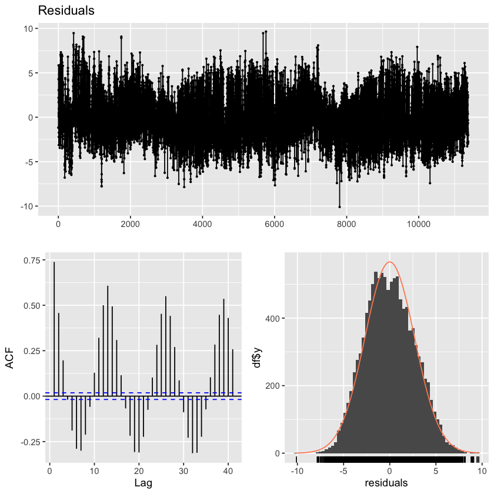

```r
checkresiduals(model_avg)
```

#### 1.b Model with Averaged Data + Time Related Regressors (Hour and Month)

```
Call:
lm(formula = production ~ . - date - hour - month + as.factor(month) +
    as.factor(hour) - production, data = avgdata[hour >= 7 &
    hour <= 18])

Residuals:
    Min      1Q  Median      3Q     Max
-9.3416 -1.2034  0.1733  1.2960  8.6601

Coefficients:
                          Estimate Std. Error t value Pr(>|t|)
(Intercept)             -4.060e+01  2.015e+00 -20.153  < 2e-16 ***
CSNOW                   -7.032e-01  1.586e-01  -4.433 9.39e-06 ***
DLWRF                   -2.940e-02  1.622e-03 -18.125  < 2e-16 ***
DSWRF                   -2.182e-03  3.166e-04  -6.892 5.81e-12 ***
TCDC_ENTIRE             -7.794e-03  1.463e-03  -5.326 1.02e-07 ***
TCDC_High_Cloud         -1.524e-03  1.177e-03  -1.295 0.195302
TCDC_Low_Cloud          -3.968e-03  1.601e-03  -2.478 0.013226 *
TCDC_Middle_Cloud       -1.154e-03  1.095e-03  -1.054 0.291963
TMP_surface              1.846e-01  8.426e-03  21.904  < 2e-16 ***
USRWF_surface            5.419e-03  7.563e-04   7.166 8.23e-13 ***
USWRF_top_of_atmosphere  2.131e-03  5.555e-04   3.836 0.000126 ***
as.factor(month)2        1.029e+00  9.437e-02  10.899  < 2e-16 ***
as.factor(month)3        1.076e+00  1.140e-01   9.443  < 2e-16 ***
as.factor(month)4        6.409e-01  1.456e-01   4.403 1.08e-05 ***
as.factor(month)5        7.970e-01  1.632e-01   4.883 1.06e-06 ***
as.factor(month)6        8.390e-01  1.834e-01   4.574 4.84e-06 ***
as.factor(month)7        6.900e-01  1.971e-01   3.500 0.000466 ***
as.factor(month)8        9.890e-02  2.126e-01   0.465 0.641841
as.factor(month)9        2.028e-01  1.754e-01   1.156 0.247773
as.factor(month)10       2.461e-01  1.313e-01   1.874 0.060947 .
as.factor(month)11      -4.655e-02  1.056e-01  -0.441 0.659422
as.factor(month)12       2.961e-02  9.734e-02   0.304 0.760979
as.factor(hour)8         2.073e+00  9.862e-02  21.018  < 2e-16 ***
as.factor(hour)9         3.176e+00  1.163e-01  27.306  < 2e-16 ***
as.factor(hour)10        3.198e+00  2.110e-01  15.155  < 2e-16 ***
as.factor(hour)11        2.814e+00  2.371e-01  11.867  < 2e-16 ***
as.factor(hour)12        2.449e+00  2.560e-01   9.567  < 2e-16 ***
as.factor(hour)13        2.000e+00  2.666e-01   7.504 6.67e-14 ***
as.factor(hour)14        1.106e+00  2.688e-01   4.114 3.92e-05 ***
as.factor(hour)15       -3.736e-01  2.634e-01  -1.418 0.156092
as.factor(hour)16       -1.920e+00  2.272e-01  -8.451  < 2e-16 ***
as.factor(hour)17       -2.942e+00  1.974e-01 -14.901  < 2e-16 ***
as.factor(hour)18       -3.173e+00  1.671e-01 -18.986  < 2e-16 ***
---
Signif. codes:  0 ‘***’ 0.001 ‘**’ 0.01 ‘*’ 0.05 ‘.’ 0.1 ‘ ’ 1

Residual standard error: 1.97 on 10463 degrees of freedom
  (61 observations deleted due to missingness)
Multiple R-squared:  0.7329,	Adjusted R-squared:  0.732
F-statistic: 896.9 on 32 and 10463 DF,  p-value: < 2.2e-16
```

```
	Breusch-Godfrey test for serial correlation of order up to 36

data:  Residuals
LM test = 4739.8, df = 36, p-value < 2.2e-16
```

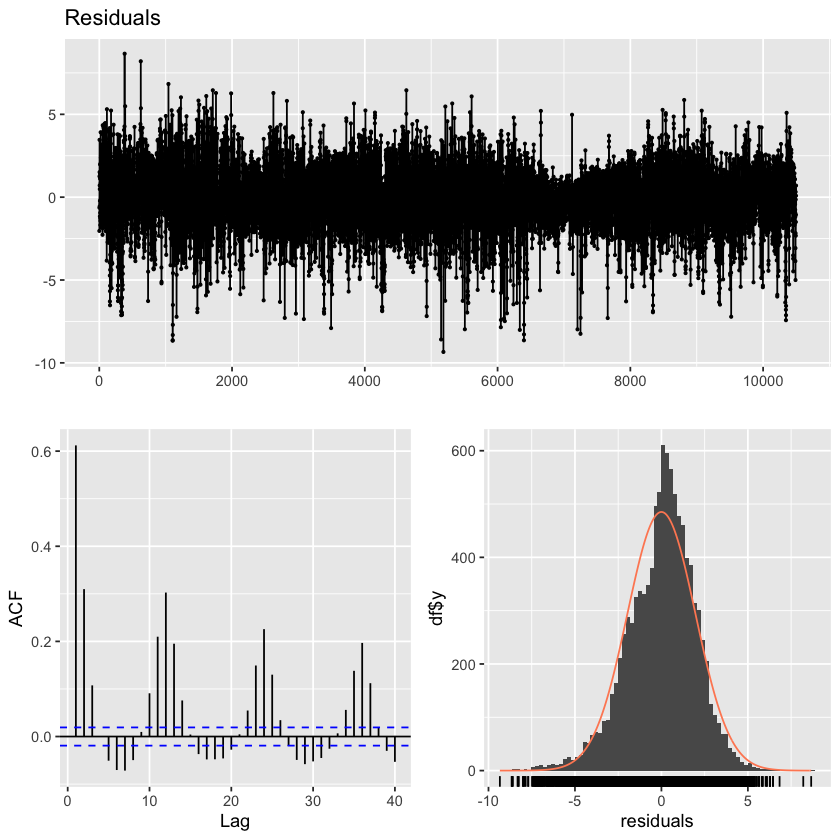

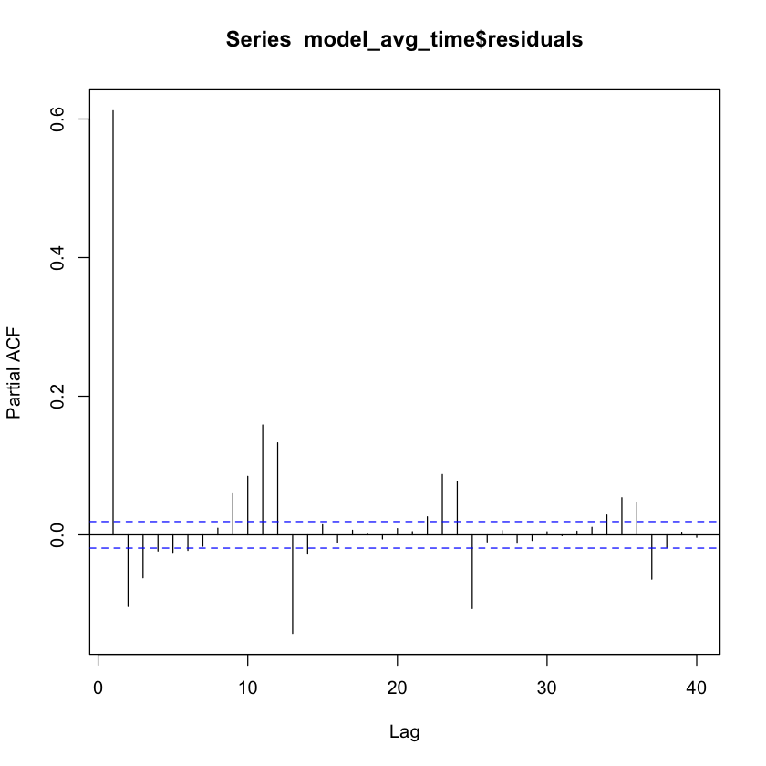

```r
#Month and hour is added as a model

model_avg_time = lm(production~.-date-hour-month+as.factor(month)+as.factor(hour)-production,avgdata[hour>=7 & hour <=18])
summary(model_avg_time)
checkresiduals(model_avg_time)
pacf(model_avg_time$residuals)
```

#### Residual plots of the averaged data+time related regressors (hour and month) model

```
	Breusch-Godfrey test for serial correlation of order up to 36

data:  Residuals
LM test = 4739.8, df = 36, p-value < 2.2e-16
```

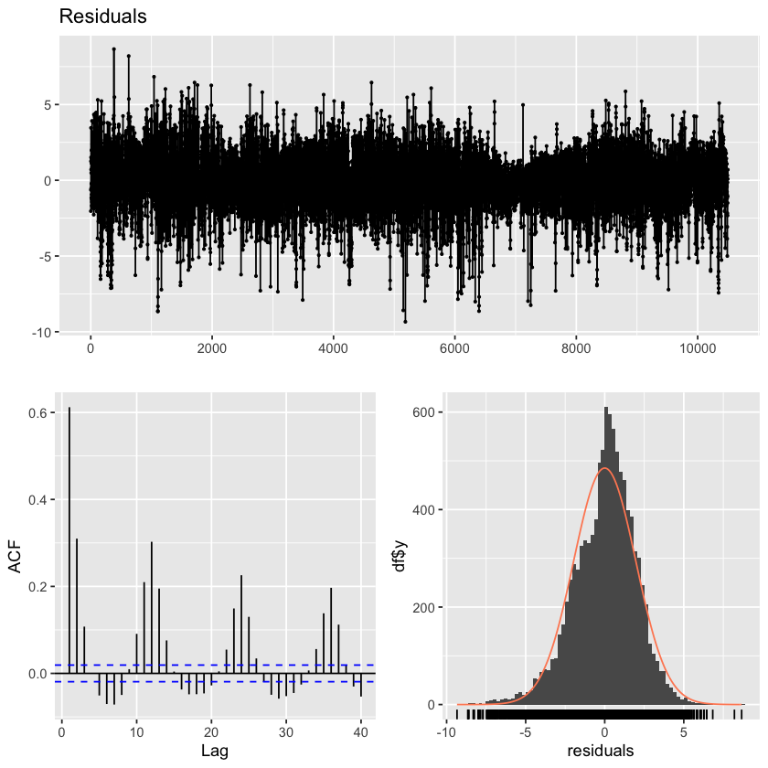

```r
checkresiduals(model_avg_time)
```

The residual plot for the linear regression model with month and time as factors provides important insights. The residuals appear to be randomly distributed around zero, indicating that the model is capturing the overall trends in the data. The ACF (Autocorrelation Function) plot shows prominent peaks at certain lags, indicating that there remains autocorrelation in the residuals. This suggests that while the model explains much of the variation in the production data, there are patterns that have not yet been fully captured. The PACF (Partial Autocorrelation Function) plot of the residuals further supports this, showing significant correlation at various lags. Despite the validity of the model, the histogram of the residuals shows an approximately normal distribution, albeit with some skewness, suggesting that the model may benefit from further refinement or the inclusion of additional predictors to fully capture the underlying patterns in the data.

### PACF plot of the residuals

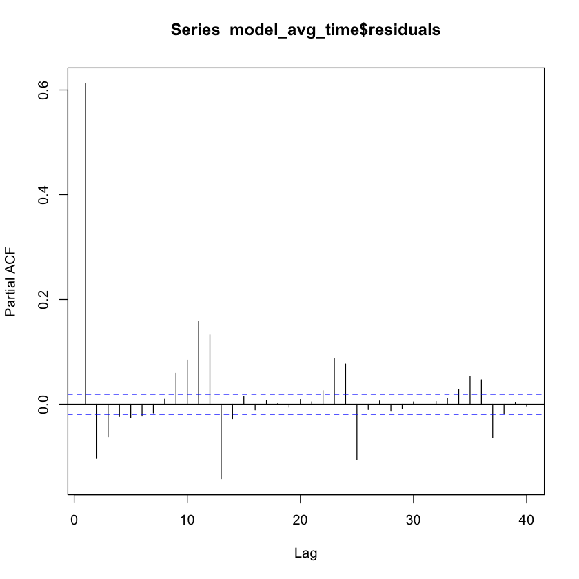

```r
pacf(model_avg_time$residuals) # pacf analysis of residuals
```

### Forecast of the Averaged Data + Time Related Regressors

```r
available_data = avgdata[!is.na(production)]
to_be_forecasted = avgdata[is.na(production)]

#FORECAST OF FOLLOWING MODEL
model_avg_time = lm(production~.-date-hour-month+as.factor(month)+as.factor(hour)-production,avgdata[hour>=7 & hour <=18])


to_be_forecasted_filtered <- subset(available_data,date >= '2024-02-01' & date == '2024-05-24' & hour >= 7 & hour <= 18)


predicted_production_time <- predict(model_avg_time, newdata = to_be_forecasted_filtered)


predicted_table_time <- data.frame(date = to_be_forecasted_filtered$date,
                                   hour = to_be_forecasted_filtered$hour,
                                   predicted_production_time = predicted_production_time)

predicted_table_time
```

A data.frame: 12 × 3

|  | date <IDate> | hour <int> | predicted_production_time <dbl> |
| --- | --- | --- | --- |
| 1 | 2024-05-24 | 7 | 3.6712138 |
| 2 | 2024-05-24 | 8 | 6.2892178 |
| 3 | 2024-05-24 | 9 | 7.9647440 |
| 4 | 2024-05-24 | 10 | 7.7711521 |
| 5 | 2024-05-24 | 11 | 7.3839362 |
| 6 | 2024-05-24 | 12 | 6.8908463 |
| 7 | 2024-05-24 | 13 | 5.8813940 |
| 8 | 2024-05-24 | 14 | 4.5850572 |
| 9 | 2024-05-24 | 15 | 2.8282400 |
| 10 | 2024-05-24 | 16 | 1.0585339 |
| 11 | 2024-05-24 | 17 | -0.0867286 |
| 12 | 2024-05-24 | 18 | -0.7003239 |

### c) Model with averaged data + time related regressors (hour and month) + lagged variables

```r
avgdata_lagged <- data.table(avgdata,lag1=c(NA,avgdata$production[1:length(avgdata$production)-1]),lag24=c(rep(NA,24),avgdata$production[1:(length(avgdata$production)-24)]))
#lag1 and lag24 added

model_avg_time_lag = lm(production~.-date-hour-month+as.factor(month)+as.factor(hour)-production,avgdata_lagged[hour>=7 & hour <=18])
summary(model_avg_time_lag) #lag1 and lag24 added
```

```
Call:
lm(formula = production ~ . - date - hour - month + as.factor(month) +
    as.factor(hour) - production, data = avgdata_lagged[hour >=
    7 & hour <= 18])

Residuals:
     Min       1Q   Median       3Q      Max
-10.0133  -0.8247   0.1215   0.8450   8.1556

Coefficients:
                          Estimate Std. Error t value Pr(>|t|)
(Intercept)             -2.9364665  1.5883421  -1.849 0.064520 .
CSNOW                   -0.2456401  0.1204404  -2.040 0.041424 *
DLWRF                   -0.0088361  0.0012522  -7.056 1.82e-12 ***
DSWRF                   -0.0015119  0.0002409  -6.276 3.62e-10 ***
TCDC_ENTIRE             -0.0045850  0.0011110  -4.127 3.71e-05 ***
TCDC_High_Cloud         -0.0003894  0.0008929  -0.436 0.662807
TCDC_Low_Cloud          -0.0014374  0.0012187  -1.179 0.238243
TCDC_Middle_Cloud       -0.0025834  0.0008314  -3.107 0.001893 **
TMP_surface              0.0255941  0.0066468   3.851 0.000119 ***
USRWF_surface            0.0001038  0.0005767   0.180 0.857176
USWRF_top_of_atmosphere  0.0005991  0.0004223   1.419 0.155989
lag1                     0.6249906  0.0078424  79.694  < 2e-16 ***
lag24                    0.1376213  0.0067799  20.298  < 2e-16 ***
as.factor(month)2        0.4224847  0.0721084   5.859 4.80e-09 ***
as.factor(month)3        0.6567458  0.0866896   7.576 3.87e-14 ***
as.factor(month)4        0.7627054  0.1105127   6.902 5.44e-12 ***
as.factor(month)5        0.8659646  0.1238981   6.989 2.93e-12 ***
as.factor(month)6        0.9816799  0.1391943   7.053 1.87e-12 ***
as.factor(month)7        0.9839930  0.1497113   6.573 5.18e-11 ***
as.factor(month)8        0.9664254  0.1615800   5.981 2.29e-09 ***
as.factor(month)9        0.7042506  0.1332428   5.285 1.28e-07 ***
as.factor(month)10       0.4720768  0.0996682   4.736 2.20e-06 ***
as.factor(month)11       0.1671097  0.0802364   2.083 0.037301 *
as.factor(month)12       0.0350034  0.0739694   0.473 0.636070
as.factor(hour)8         0.8647542  0.0766238  11.286  < 2e-16 ***
as.factor(hour)9         0.7599516  0.0931756   8.156 3.86e-16 ***
as.factor(hour)10        0.4622402  0.1635483   2.826 0.004718 **
as.factor(hour)11        0.2133966  0.1826521   1.168 0.242703
as.factor(hour)12        0.1210706  0.1963031   0.617 0.537411
as.factor(hour)13       -0.1125895  0.2038881  -0.552 0.580815
as.factor(hour)14       -0.7135410  0.2051129  -3.479 0.000506 ***
as.factor(hour)15       -1.5604323  0.2005699  -7.780 7.94e-15 ***
as.factor(hour)16       -2.3292552  0.1733806 -13.434  < 2e-16 ***
as.factor(hour)17       -2.3227174  0.1513787 -15.344  < 2e-16 ***
as.factor(hour)18       -2.0424733  0.1290284 -15.830  < 2e-16 ***
---
Signif. codes:  0 ‘***’ 0.001 ‘**’ 0.01 ‘*’ 0.05 ‘.’ 0.1 ‘ ’ 1

Residual standard error: 1.493 on 10449 degrees of freedom
  (73 observations deleted due to missingness)
Multiple R-squared:  0.8466,	Adjusted R-squared:  0.8461
F-statistic:  1696 on 34 and 10449 DF,  p-value: < 2.2e-16
```

Model 2 uses time and lagged variables to predict solar power production, achieving an adjusted R² of 84.6%. The model includes 1-hour (lag1) and 24-hour (lag24) lagged variables to capture time-dependent patterns. A linear regression model incorporating month and hour as factors predicts production between 07:00 and 18:00. Residual analysis indicates the model captures the overall trend well, though some autocorrelation remains at specific lags. This approach effectively captures the time-dependent and autocorrelated nature of solar power production.

```
	Breusch-Godfrey test for serial correlation of order up to 38

data:  Residuals
LM test = 722.81, df = 38, p-value < 2.2e-16
```

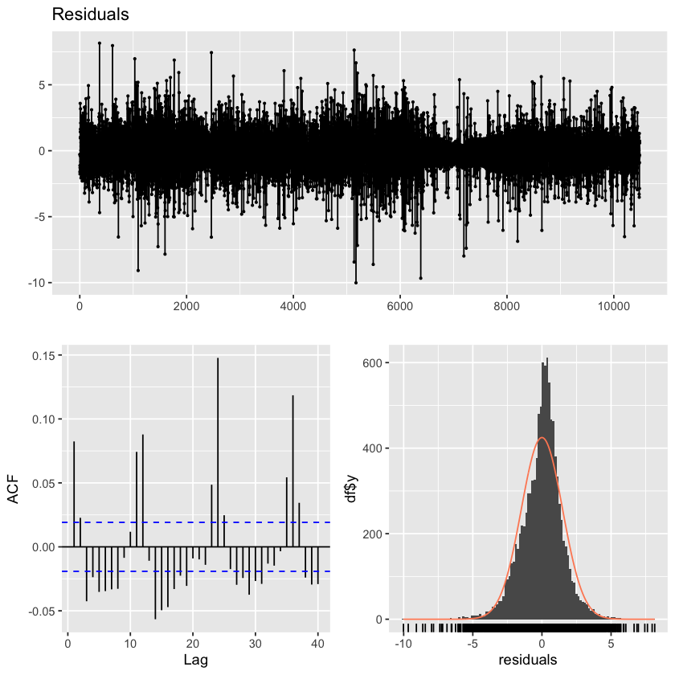

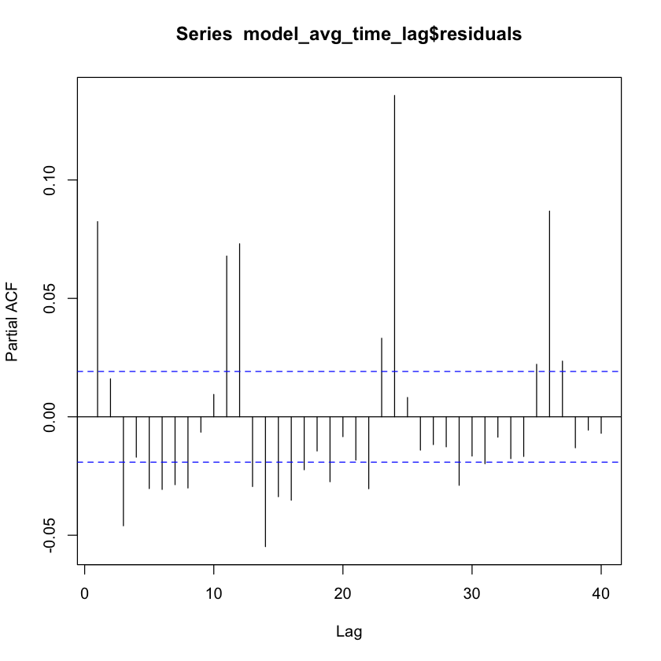

```r
checkresiduals(model_avg_time_lag)
pacf(model_avg_time_lag$residuals)
```

## 2) ARIMA Models

### 2.a) auto.arima Model

```r
ForecastReportAutoAr <- function(x_date) {

arima_vec <- rep(NA,24)
for (i in 0:23){
  dataf <- avgdata[date >= train_start & date < x_date & hour == i,c("date","production")]
  dataf <- ts(dataf)
  fitted=auto.arima(dataf[,'production'],seasonal = T,trace=F)
  forecasted1=forecast(fitted,h=3)
  arima_vec[i+1]<-forecasted1$mean[3]
}
return(arima_vec)
}
#reporting accuracy
accu=function(actual,forecast){
  n=length(actual)
  error=actual-forecast
  mean=mean(actual)
  sd=sd(actual)
  CV=sd/mean
  FBias=sum(error)/sum(actual)
  MAPE=sum(abs(error/actual))/n
  RMSE=sqrt(sum(error^2)/n)
  MAD=sum(abs(error))/n
  MADP=sum(abs(error))/sum(abs(actual))
  WMAPE=MAD/mean
  l=data.frame(n,mean,sd,CV,FBias,MAPE,RMSE,MAD,MADP,WMAPE)
  return(l)
}
```

```r
forecast_autoar = ForecastReportAutoAr("2024-05-24")
```

## auto.arima with 1 regressor

"TMP_surface" is one of the significant variable in regression analysis in auto.arima model.

```r
ForecastReportArimax <- function(x_date) {
arima_vec_reg <- rep(NA,24)
for(i in 0:23) {
  dataf <- avgdata[date >= train_start & date < as.Date(x_date) -2 & hour == i,c("date","production")]
  dataf <- ts(dataf)
  regressor <- avgdata[date >= train_start & date < as.Date(x_date) -2 & hour == i,c("TMP_surface")]
  fitted_reg <- auto.arima(dataf[,'production'],xreg=data.matrix(regressor))
  regforecast <- avgdata[(date==x_date & hour==i) |(date==as.Date(x_date)+1 & hour==i)|date==as.Date(x_date)+2 & hour==i,c("TMP_surface")]
  forecasted2=forecast(fitted_reg,xreg=data.matrix(regforecast),h=2)
  arima_vec_reg[i+1] <- forecasted2$mean[2]
}
return(arima_vec_reg)
}
```

```r
ForecastReportArimax1 <- function(x_date) {
arima_vec_reg <- rep(NA,24)
for(i in 0:23) {
  dataf <- avgdata[date >= train_start & date < as.Date(x_date) -2 & hour == i,c("date","production")]
  dataf <- ts(dataf)
  regressor <- avgdata[date >= train_start & date < as.Date(x_date) -2 & hour == i,c("TCDC_Middle_Cloud")]
  fitted_reg <- auto.arima(dataf[,'production'],xreg=data.matrix(regressor))
  regforecast <- avgdata[(date==x_date & hour==i) |(date==as.Date(x_date)+1 & hour==i)|date==as.Date(x_date)+2 & hour==i,c("TCDC_Middle_Cloud")]
  forecasted2=forecast(fitted_reg,xreg=data.matrix(regforecast),h=1)
  arima_vec_reg[i+1] <- forecasted2$mean[1]
}
return(arima_vec_reg)
}
```

```r
forecast_arimax1 = ForecastReportArimax1("2024-05-26")
```

```r
forecast_arimax = ForecastReportArimax("2024-05-26")
```

## auto.arima with 2 regressors

Moreover, we added "DLWRF" variable as second one to our model.

```r
ForecastReportArimax2<- function(x_date) {
arima_vec_reg2 <- rep(NA,24)
for(i in 0:23) {
  dataf <- avgdata[date >= train_start & date < as.Date(x_date)-2 & hour == i,c("date","production")]
    dataf <- ts(dataf)
    regressor <- avgdata[date >= train_start & date < as.Date(x_date)-2 & hour == i,c("DLWRF","TMP_surface")]
  fitted_reg <- auto.arima(dataf[,'production'], xreg=data.matrix(regressor))
  regforecast <- avgdata[(date==x_date & hour==i) |(date==as.Date(x_date)+1 & hour==i |date==as.Date(x_date)+2 & hour==i),c("DLWRF","TMP_surface")]
  forecasted2=forecast(fitted_reg,xreg=data.matrix(regforecast),h=1)
  arima_vec_reg2[i+1] <- forecasted2$mean[1]
}
return(arima_vec_reg2)
}
```

```r
forecast_arimax2 = ForecastReportArimax2("2024-05-24")
```

```r
round_to_5_decimal <- function(x) {
  return(round(x, 5))
}
```

## auto.arima with 6 regressors

So currently we tried "TMP_surface","DLWRF","TCDC_ENTIRE", "TCDC_High_Cloud", "TCDC_Low_Cloud", "TCDC_Middle_Cloud" which were also significant on linear model. For the second half of the submission period, we realized our first model has lots of dicrepancies and we tried to improved it. Therefore, in one of our trials we realized this current model gives less WMAPE score than our first one. Therefore, we proceed using this model for the rest of the competition phase.

```r
ForecastReportArimax6<- function(x_date) {
arima_vec_reg2 <- rep(NA,24)
for(i in 0:23) {
  dataf <- avgdata[date >= train_start & date < as.Date(x_date)-2 & hour == i,c("date","production")]
    dataf <- ts(dataf)
    regressor <- avgdata[date >= train_start & date < as.Date(x_date)-2 & hour == i,c("TMP_surface","DLWRF","TCDC_ENTIRE", "TCDC_High_Cloud",	"TCDC_Low_Cloud", "TCDC_Middle_Cloud")]
  fitted_reg <- auto.arima(dataf[,'production'], xreg=data.matrix(regressor))
  regforecast <- avgdata[(date==x_date & hour==i) |(date==as.Date(x_date)+1 & hour==i |date==as.Date(x_date)+2 & hour==i),c("TMP_surface","DLWRF","TCDC_ENTIRE", "TCDC_High_Cloud",	"TCDC_Low_Cloud",  "TCDC_Middle_Cloud")]
  forecasted2=forecast(fitted_reg,xreg=data.matrix(regforecast),h=1)
  arima_vec_reg2[i+1] <- forecasted2$mean[1]
}
return(arima_vec_reg2)
}
```

```r
forecast_arimax6 = ForecastReportArimax6("2024-05-26")
```

```r
dataf <- avgdata[date >= train_start & date < as.Date("2024-05-23")-2 & hour == 4,c("date","production")]
regressor <- avgdata[date >= train_start & date < as.Date("2024-05-23")-2 & hour == 4,c("DLWRF","TMP_surface")]

fitted_reg <- auto.arima(dataf[,'production'], xreg=data.matrix(regressor))
regforecast <- avgdata[(date=="2024-05-23" & hour==4) |(date==as.Date("2024-05-23")+1 & hour==4 |date==as.Date("2024-05-23")+2 & hour==4),c("DLWRF","TMP_surface")]
regforecast
forecasted2=forecast(fitted_reg,xreg=data.matrix(regforecast),h=1)
forecasted2
forecasted2$mean[3]
```

A data.table: 3 × 2

| DLWRF <dbl> | TMP_surface <dbl> |
| --- | --- |
| 310.904 | 285.0480 |
| 287.446 | 283.1184 |
| 341.365 | 282.9460 |

```
    Point Forecast      Lo 80     Hi 80      Lo 95     Hi 95
870     0.10069754 0.08185901 0.1195361 0.07188650 0.1295086
871     0.10133262 0.07469092 0.1279743 0.06058766 0.1420776
872     0.09967272 0.06704344 0.1323020 0.04977054 0.1495749
```

0.0996727165039056

### Accuracy of The Models

```r
avgdata$date <- as.Date(avgdata$date)

production_data <- subset(avgdata, date == as.Date("2024-05-20"))

production_values <- production_data$production
production_values
```

1. 0

2. 0

3. 0

4. 0

5. 0.1

6. 0.75

7. 1.71

8. 2.82

9. 4.43

10. 7.07

11. 8.79

12. 8

13. 5.58

14. 7.28

15. 4.94

16. 3.76

17. 3.42

18. 1.28

19. 0.23

20. 0

21. 0

22. 0

23. 0

24. 0

```r
forecast_arimax6 = ForecastReportArimax6("2024-05-20")
forecast_arimax2 = ForecastReportArimax2("2024-05-20")
forecast_arimax1 = ForecastReportArimax1("2024-05-20")
forecast_arimax = ForecastReportArimax("2024-05-20")
forecast_autoar = ForecastReportAutoAr("2024-05-20")
accu(production_values, forecast_arimax6)
accu(production_values, forecast_arimax2)
accu(production_values, forecast_arimax1)
accu(production_values, forecast_arimax)
accu(production_values, forecast_autoar)
```

A data.frame: 1 × 10

| n <int> | mean <dbl> | sd <dbl> | CV <dbl> | FBias <dbl> | MAPE <dbl> | RMSE <dbl> | MAD <dbl> | MADP <dbl> | WMAPE <dbl> |
| --- | --- | --- | --- | --- | --- | --- | --- | --- | --- |
| 24 | 2.506667 | 3.00424 | 1.1985 | -0.03116658 | NaN | 0.9474598 | 0.5520537 | 0.2202342 | 0.2202342 |

A data.frame: 1 × 10

| n <int> | mean <dbl> | sd <dbl> | CV <dbl> | FBias <dbl> | MAPE <dbl> | RMSE <dbl> | MAD <dbl> | MADP <dbl> | WMAPE <dbl> |
| --- | --- | --- | --- | --- | --- | --- | --- | --- | --- |
| 24 | 2.506667 | 3.00424 | 1.1985 | 0.009250146 | NaN | 0.8871042 | 0.5114421 | 0.2040328 | 0.2040328 |

A data.frame: 1 × 10

| n <int> | mean <dbl> | sd <dbl> | CV <dbl> | FBias <dbl> | MAPE <dbl> | RMSE <dbl> | MAD <dbl> | MADP <dbl> | WMAPE <dbl> |
| --- | --- | --- | --- | --- | --- | --- | --- | --- | --- |
| 24 | 2.506667 | 3.00424 | 1.1985 | -0.05661767 | NaN | 0.8351183 | 0.5308169 | 0.2117621 | 0.2117621 |

A data.frame: 1 × 10

| n <int> | mean <dbl> | sd <dbl> | CV <dbl> | FBias <dbl> | MAPE <dbl> | RMSE <dbl> | MAD <dbl> | MADP <dbl> | WMAPE <dbl> |
| --- | --- | --- | --- | --- | --- | --- | --- | --- | --- |
| 24 | 2.506667 | 3.00424 | 1.1985 | -0.2412262 | NaN | 1.112983 | 0.6557916 | 0.261619 | 0.261619 |

A data.frame: 1 × 10

| n <int> | mean <dbl> | sd <dbl> | CV <dbl> | FBias <dbl> | MAPE <dbl> | RMSE <dbl> | MAD <dbl> | MADP <dbl> | WMAPE <dbl> |
| --- | --- | --- | --- | --- | --- | --- | --- | --- | --- |
| 24 | 2.506667 | 3.00424 | 1.1985 | -0.1601362 | NaN | 1.008241 | 0.5819382 | 0.2321562 | 0.2321562 |

## AIC BIC

```r
ForecastReportArimax2_AIC <- function(x_date) {
  arima_vec_reg2 <- rep(NA, 24)
  aic_values <- rep(NA, 24)
  bic_values <- rep(NA, 24)

  for(i in 0:23) {
    dataf <- avgdata[date >= train_start & date < as.Date(x_date)-2 & hour == i, c("date", "production")]
    dataf <- ts(dataf[, "production"])  # Ensure 'dataf' is a time series of production
    regressor <- avgdata[date >= train_start & date < as.Date(x_date)-2 & hour == i, c("DLWRF", "TMP_surface")]

    fitted_reg <- auto.arima(dataf, xreg = data.matrix(regressor))

    # Store AIC and BIC values
    aic_values[i + 1] <- AIC(fitted_reg)
    bic_values[i + 1] <- BIC(fitted_reg)

    regforecast <- avgdata[(date == x_date & hour == i) |
                           (date == as.Date(x_date) + 1 & hour == i) |
                           (date == as.Date(x_date) + 2 & hour == i),
                           c("DLWRF", "TMP_surface")]
    forecasted2 <- forecast(fitted_reg, xreg = data.matrix(regforecast), h = 1)
    arima_vec_reg2[i + 1] <- forecasted2$mean[1]
  }

  return(list(forecast = arima_vec_reg2, AIC = aic_values, BIC = bic_values))
}
```

```r
ForecastReportArimax2_AIC("2024-05-20")
```

**$forecast**

1. 0

2. 0

3. 0

4. 0

5. 0.0404457152594016

6. 0.686810373253903

7. 2.46616872987695

8. 5.1187538957535

9. 6.29437949315316

10. 7.30249150281727

11. 7.12213086726937

12. 6.20369229111642

13. 5.85770562034897

14. 5.82228366353765

15. 4.8673495792197

16. 4.18936521937703

17. 2.39423075205666

18. 1.10016510709738

19. 0.137341483395275

20. 0.000196932208285848

21. 0

22. 0

23. 0

24. 0

**$AIC**

1. -Inf

2. -Inf

3. -Inf

4. -Inf

5. -5071.72021909841

6. -1311.6987808597

7. 1492.34557530149

8. 3017.8491031546

9. 3527.69791251046

10. 3765.80688725449

11. 3826.91738213522

12. 3793.32390288214

13. 3791.7758624202

14. 3859.76736562764

15. 3769.71850387985

16. 3423.96805026461

17. 2972.75078317834

18. 1938.99745529411

19. 148.679301824991

20. -9312.78590457353

21. -Inf

22. -Inf

23. -Inf

24. -Inf

**$BIC**

1. -Inf

2. -Inf

3. -Inf

4. -Inf

5. -5052.66930107069

6. -1292.64324122545

7. 1516.16499984431

8. 3055.95093921005

9. 3556.28122196183

10. 3789.6263117973

11. 3865.02846140371

12. 3826.67917571961

13. 3815.58950995486

14. 3878.82290526189

15. 3793.53792842266

16. 3447.78169779927

17. 2996.57020772115

18. 1962.81687983692

19. 167.734841459241

20. -9298.49078764318

21. -Inf

22. -Inf

23. -Inf

24. -Inf

# Results, Conclusions and Future Work

Although our model performed well in predicting solar power production, there are several areas for improvement and further research. Firstly, more advanced analysis techniques can be used together. Adding external regressors and exploring different ARIMA models might yield better results. Moreover, analyzing critical hours with very low or zero production can provide insights into refining the model to handle such cases more effectively. So the times that at the beginning we discarded might be also added. Additionally, identifying other relevant parameters for correlation, such as wind speed, atmospheric pressure, and humidity, could provide more comprehensive insights and improve the model's predictive power. However, it is important to not fall into overpredicting side of the modelling as well. From next tables, submitted and actual data can be found. Even though some issues has been gone through with submission of 14th of May.

MAY 14TH

| Hours | Submitted Prediction | Actual Data |
| --- | --- | --- |
| 00:00 | 0.000 | 0.000 |
| 01:00 | 0.000 | 0.000 |
| 02:00 | 0.000 | 0.000 |
| 03:00 | 0.000 | 0.000 |
| 04:00 | 0.000 | 0.070 |
| 05:00 | 0.000 | 0.960 |
| 06:00 | 2.998 | 2.590 |
| 07:00 | 5.310 | 4.140 |
| 08:00 | 6.489 | 7.600 |
| 09:00 | 6.421 | 8.830 |
| 10:00 | 6.707 | 7.440 |
| 11:00 | 7.203 | 5.840 |
| 12:00 | 7.455 | 7.780 |
| 13:00 | 6.702 | 9.640 |
| 14:00 | 5.148 | 9.700 |
| 15:00 | 3.908 | 7.820 |
| 16:00 | 2.496 | 4.550 |
| 17:00 | 1.741 | 1.330 |
| 18:00 | 1.416 | 0.140 |
| 19:00 | 0.000 | 0.000 |
| 20:00 | 0.000 | 0.000 |
| 21:00 | 0.000 | 0.000 |
| 22:00 | 0.000 | 0.000 |
| 23:00 | 0.000 | 0.000 |

MAY 15TH

| Hours | Submitted Prediction | Actual Data |
| --- | --- | --- |
| 00:00 | 0.000 | 0.000 |
| 01:00 | 0.000 | 0.000 |
| 02:00 | 0.000 | 0.000 |
| 03:00 | 0.000 | 0.000 |
| 04:00 | 0.000 | 0.080 |
| 05:00 | 0.000 | 0.840 |
| 06:00 | 3.341 | 2.940 |
| 07:00 | 5.947 | 6.580 |
| 08:00 | 7.696 | 9.130 |
| 09:00 | 7.990 | 9.820 |
| 10:00 | 8.194 | 9.870 |
| 11:00 | 8.054 | 9.820 |
| 12:00 | 7.589 | 7.920 |
| 13:00 | 6.350 | 7.180 |
| 14:00 | 4.436 | 6.000 |
| 15:00 | 1.816 | 3.110 |
| 16:00 | 0.573 | 2.500 |
| 17:00 | 0.094 | 0.830 |
| 18:00 | 0.000 | 0.280 |
| 19:00 | 0.000 | 0.000 |
| 20:00 | 0.000 | 0.000 |
| 21:00 | 0.000 | 0.000 |
| 22:00 | 0.000 | 0.000 |
| 23:00 | 0.000 | 0.000 |

MAY 16TH

| Hours | Submitted Prediction | Actual Data |
| --- | --- | --- |
| 00:00 | 0.000 | 0.000 |
| 01:00 | 0.000 | 0.000 |
| 02:00 | 0.000 | 0.000 |
| 03:00 | 0.000 | 0.000 |
| 04:00 | 0.000 | 0.040 |
| 05:00 | 0.000 | 0.600 |
| 06:00 | 0.000 | 2.890 |
| 07:00 | 4.279 | 6.450 |
| 08:00 | 7.112 | 8.390 |
| 09:00 | 8.886 | 8.390 |
| 10:00 | 8.733 | 2.820 |
| 11:00 | 8.173 | 4.960 |
| 12:00 | 7.067 | 5.520 |
| 13:00 | 6.107 | 8.890 |
| 14:00 | 5.132 | 9.500 |
| 15:00 | 3.513 | 5.320 |
| 16:00 | 1.081 | 2.880 |
| 17:00 | 0.077 | 1.270 |
| 18:00 | 0.427 | 0.160 |
| 19:00 | 0.376 | 0.000 |
| 20:00 | 0.000 | 0.000 |
| 21:00 | 0.000 | 0.000 |
| 22:00 | 0.000 | 0.000 |
| 23:00 | 0.000 | 0.000 |

MAY 17TH

| Hours | Submitted Prediction | Actual Data |
| --- | --- | --- |
| 00:00 | 0.000 | 0.000 |
| 01:00 | 0.000 | 0.000 |
| 02:00 | 0.000 | 0.000 |
| 03:00 | 0.000 | 0.000 |
| 04:00 | 0.000 | 0.040 |
| 05:00 | 0.000 | 0.760 |
| 06:00 | 4.406 | 2.430 |
| 07:00 | 7.345 | 4.230 |
| 08:00 | 9.074 | 5.460 |
| 09:00 | 8.753 | 9.420 |
| 10:00 | 8.573 | 8.640 |
| 11:00 | 7.906 | 4.900 |
| 12:00 | 6.691 | 6.710 |
| 13:00 | 5.361 | 7.890 |
| 14:00 | 3.564 | 5.080 |
| 15:00 | 1.024 | 6.780 |
| 16:00 | 0.082 | 3.310 |
| 17:00 | 0.405 | 1.500 |
| 18:00 | 0.338 | 0.180 |
| 19:00 | 0.000 | 0.000 |
| 20:00 | 0.000 | 0.000 |
| 21:00 | 0.000 | 0.000 |
| 22:00 | 0.000 | 0.000 |
| 23:00 | 0.000 | 0.000 |

MAY 18TH

| Hours | Submitted Prediction | Actual Data |
| --- | --- | --- |
| 00:00 | 0.000 | 0.000 |
| 01:00 | 0.000 | 0.000 |
| 02:00 | 0.000 | 0.000 |
| 03:00 | 0.000 | 0.000 |
| 04:00 | 0.000 | 0.150 |
| 05:00 | 0.000 | 0.980 |
| 06:00 | 3.541 | 2.830 |
| 07:00 | 6.382 | 5.810 |
| 08:00 | 8.185 | 8.530 |
| 09:00 | 8.320 | 9.800 |
| 10:00 | 8.430 | 9.830 |
| 11:00 | 8.283 | 9.830 |
| 12:00 | 7.848 | 9.640 |
| 13:00 | 6.690 | 9.780 |
| 14:00 | 4.815 | 9.280 |
| 15:00 | 2.958 | 7.170 |
| 16:00 | 1.713 | 4.160 |
| 17:00 | 1.065 | 1.310 |
| 18:00 | 0.000 | 0.200 |
| 19:00 | 0.000 | 0.000 |
| 20:00 | 0.000 | 0.000 |
| 21:00 | 0.000 | 0.000 |
| 22:00 | 0.000 | 0.000 |
| 23:00 | 0.000 | 0.000 |

MAY 19TH

| Hours | Submitted Prediction | Actual Data |
| --- | --- | --- |
| 00:00 | 0.000 | 0.000 |
| 01:00 | 0.000 | 0.000 |
| 02:00 | 0.000 | 0.000 |
| 03:00 | 0.000 | 0.000 |
| 04:00 | 0.000 | 0.000 |
| 05:00 | 0.000 | 0.850 |
| 06:00 | 2.814 | 3.380 |
| 07:00 | 5.591 | 6.460 |
| 08:00 | 7.461 | 9.050 |
| 09:00 | 8.117 | 8.250 |
| 10:00 | 8.070 | 8.750 |
| 11:00 | 7.818 | 9.880 |
| 12:00 | 7.409 | 8.780 |
| 13:00 | 6.431 | 9.780 |
| 14:00 | 4.702 | 7.410 |
| 15:00 | 2.656 | 4.200 |
| 16:00 | 1.106 | 2.790 |
| 17:00 | 0.537 | 1.000 |
| 18:00 | 0.000 | 0.070 |
| 19:00 | 0.000 | 0.000 |
| 20:00 | 0.000 | 0.000 |
| 21:00 | 0.000 | 0.000 |
| 22:00 | 0.000 | 0.000 |
| 23:00 | 0.000 | 0.000 |

MAY 20TH

[output not shown]

MAY 21TH

| Hours | Submitted Prediction | Actual Data |
| --- | --- | --- |
| 00:00 | 0.000 | 0.000 |
| 01:00 | 0.000 | 0.000 |
| 02:00 | 0.000 | 0.000 |
| 03:00 | 0.000 | 0.000 |
| 04:00 | 0.000 | 0.090 |
| 05:00 | 0.000 | 0.720 |
| 06:00 | 3.775 | 2.850 |
| 07:00 | 6.555 | 5.880 |
| 08:00 | 8.410 | 8.420 |
| 09:00 | 8.727 | 7.730 |
| 10:00 | 8.779 | 5.260 |
| 11:00 | 8.451 | 5.000 |
| 12:00 | 7.592 | 3.950 |
| 13:00 | 5.878 | 7.760 |
| 14:00 | 3.704 | 8.100 |
| 15:00 | 1.686 | 4.670 |
| 16:00 | 0.386 | 3.550 |
| 17:00 | 0.000 | 1.490 |
| 18.00 | 0.000 | 0.210 |
| 19:00 | 0.000 | 0.000 |
| 20:00 | 0.000 | 0.000 |
| 21:00 | 0.000 | 0.000 |
| 22:00 | 0.000 | 0.000 |
| 23:00 | 0.000 | 0.000 |

MAY 22TH

| Hours | Submitted Prediction | Actual Data |
| --- | --- | --- |
| 00:00 | 0.000 | 0.000 |
| 01:00 | 0.000 | 0.000 |
| 02:00 | 0.000 | 0.000 |
| 03:00 | 0.000 | 0.000 |
| 04:00 | 0.000 | 0.070 |
| 05:00 | 0.000 | 0.590 |
| 06:00 | 4.843 | 2.920 |
| 07:00 | 7.758 | 6.240 |
| 08:00 | 9.476 | 8.940 |
| 09:00 | 9.121 | 9.860 |
| 10:00 | 9.095 | 9.850 |
| 11:00 | 8.936 | 9.830 |
| 12:00 | 8.524 | 9.910 |
| 13:00 | 7.523 | 9.830 |
| 14:00 | 5.793 | 9.390 |
| 15:00 | 4.095 | 6.460 |
| 16:00 | 2.752 | 3.120 |
| 17:00 | 2.045 | 0.970 |
| 18:00 | 0.000 | 0.080 |
| 19:00 | 0.000 | 0.000 |
| 20:00 | 0.000 | 0.000 |
| 21:00 | 0.000 | 0.000 |
| 22:00 | 0.000 | 0.000 |
| 23:00 | 0.000 | 0.000 |

MAY 23TH

| Hours | Submitted Prediction | Actual Data |
| --- | --- | --- |
| 00:00 | 0.000 | 0.000 |
| 01:00 | 0.000 | 0.000 |
| 02:00 | 0.000 | 0.000 |
| 03:00 | 0.000 | 0.000 |
| 04:00 | 0.000 | 0.070 |
| 05:00 | 0.000 | 1.000 |
| 06:00 | 4.445 | 2.620 |
| 07:00 | 7.496 | 5.900 |
| 08:00 | 9.442 | 8.500 |
| 09:00 | 9.505 | 9.770 |
| 10:00 | 9.437 | 9.850 |
| 11:00 | 9.050 | 9.680 |
| 12:00 | 8.437 | 9.400 |
| 13:00 | 7.368 | 8.190 |
| 14:00 | 5.546 | 8.250 |
| 15:00 | 3.134 | 4.990 |
| 16:00 | 1.602 | 2.800 |
| 17:00 | 0.898 | 0.860 |
| 18:00 | 0.475 | 0.090 |
| 19:00 | 0.000 | 0.000 |
| 20:00 | 0.000 | 0.000 |
| 21:00 | 0.000 | 0.000 |
| 22:00 | 0.000 | 0.000 |
| 23:00 | 0.000 | 0.000 |

MAY 24th

| Hours | Submitted Prediction | Actual Data |
| --- | --- | --- |
| 00:00 | 0.000 | 0.000 |
| 01:00 | 0.000 | 0.000 |
| 02:00 | 0.000 | 0.000 |
| 03:00 | 0.000 | 0.000 |
| 04:00 | 0.090 | 0.000 |
| 05:00 | 0.755 | 0.020 |
| 06:00 | 2.639 | 0.020 |
| 07:00 | 5.058 | 2.490 |
| 08:00 | 6.815 | 2.430 |
| 09:00 | 7.276 | 4.890 |
| 10:00 | 6.668 | 2.770 |
| 11:00 | 6.662 | 5.210 |
| 12:00 | 5.883 | 7.210 |
| 13:00 | 6.292 | 5.740 |
| 14:00 | 5.184 | 2.260 |
| 15:00 | 3.395 | 2.090 |
| 16:00 | 2.573 | 2.810 |
| 17:00 | 1.123 | 1.000 |
| 18:00 | 0.142 | 0.070 |
| 19:00 | 0.000 | 0.000 |
| 20:00 | 0.000 | 0.000 |
| 21:00 | 0.000 | 0.000 |
| 22:00 | 0.000 | 0.000 |
| 23:00 | 0.000 | 0.000 |

MAY 25th

| Hours | Submitted Prediction | Actual Data |
| --- | --- | --- |
| 00:00 | 0.000 | 0.000 |
| 01:00 | 0.000 | 0.000 |
| 02:00 | 0.000 | 0.000 |
| 03:00 | 0.000 | 0.000 |
| 04:00 | 0.069 | 0.010 |
| 05:00 | 0.722 | 0.600 |
| 06:00 | 2.577 | 0.900 |
| 07:00 | 3.849 | 0.820 |
| 08:00 | 4.372 | 1.710 |
| 09:00 | 4.329 | 3.570 |
| 10:00 | 4.109 | 2.400 |
| 11:00 | 4.363 | 2.650 |
| 12:00 | 3.583 | 6.400 |
| 13:00 | 3.991 | 8.200 |
| 14:00 | 4.335 | 5.750 |
| 15:00 | 3.529 | 5.470 |
| 16:00 | 2.327 | 3.780 |
| 17:00 | 0.915 | 0.690 |
| 18:00 | 0.137 | 0.240 |
| 19:00 | 0.000 | 0.000 |
| 20:00 | 0.000 | 0.000 |
| 21:00 | 0.000 | 0.000 |
| 22:00 | 0.000 | 0.000 |
| 23:00 | 0.000 | 0.000 |

MAY 26th

| Hours | Submitted Prediction | Actual Data |
| --- | --- | --- |
| 00:00 | 0.000 | 0.000 |
| 01:00 | 0.000 | 0.000 |
| 02:00 | 0.000 | 0.000 |
| 03:00 | 0.000 | 0.000 |
| 04:00 | 0.085 | 0.090 |
| 05:00 | 0.780 | 0.580 |
| 06:00 | 2.692 | 2.970 |
| 07:00 | 5.840 | 4.600 |
| 08:00 | 8.782 | 8.220 |
| 09:00 | 9.746 | 7.520 |
| 10:00 | 9.213 | 8.070 |
| 11:00 | 9.035 | 7.280 |
| 12:00 | 8.757 | 9.320 |
| 13:00 | 8.533 | 9.450 |
| 14:00 | 7.668 | 7.410 |
| 15:00 | 5.040 | 5.250 |
| 16:00 | 2.858 | 1.530 |
| 17:00 | 1.015 | 0.640 |
| 18:00 | 0.159 | 0.190 |
| 19:00 | 0.000 | 0.000 |
| 20:00 | 0.000 | 0.000 |
| 21:00 | 0.000 | 0.000 |
| 22:00 | 0.000 | 0.000 |
| 23:00 | 0.000 | 0.000 |